### M13801712

# AEEM 3013 Exam 2

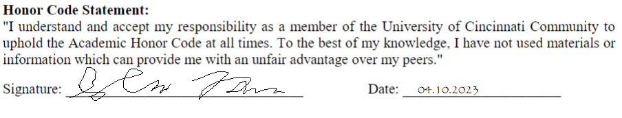

## Problem 1. Projectile and Shock

### Given

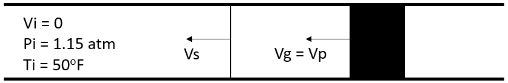

Given the diagram above with $V_p$ varying from 900 to 1450 ft/s, plot $V_s$ and $T_g$ versus $V_p$ and explain the trends.

### Assumptions

- steady, uniform flow
- isentropic everywhere except shock
- air is CPG with $\gamma=1.4$, $R=53.35$ $\text{ft lbf}/\text{lb} ^\circ \text{R}$

### Analysis

First do a coordinate transformation to analyze with a stationary shock (so regular shock relation equations apply):

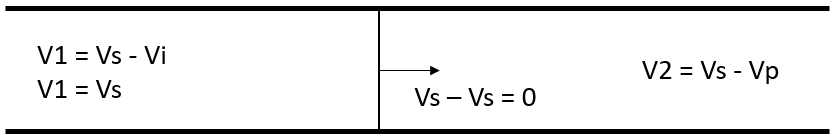

$T_1 = T_i = 50^\circ \text{F} = 509.67^\circ \text{R}$

$P_1 = P_i = 1.15 \text{atm}$

We can use the equation for $V_s$ that is derived from static shock relation equations:

$$ V_s = \frac{\gamma+1}{4}V_g+\frac{1}{2}\sqrt{(\frac{\gamma+1}{2})^2V_g^2+4\gamma RT_1} $$

We must convert R to usable units: $$ R = \frac{53.35\text{ft lbf}}{\text{lbm $^\circ$R}}*\frac{32.2 \text{ft lbm}}{\text{lbf s$^2$}} = 1717.87 \frac{\text{ft $^2$}}{\text{s $^2$ $^\circ$R}} $$

$$ \fbox{$V_s = \frac{\gamma+1}{4}V_g+\frac{1}{2}\sqrt{(\frac{\gamma+1}{2})^2V_g^2+6871.5\gamma T_1}$} $$

We will need to calculate $M_1$ and $M_2$: $$ M_1 = \frac{V_1}{\sqrt{\gamma RT_1}} = \frac{V_1}{\sqrt{1717.87\gamma T_1}} $$

$$ M_2 = \sqrt{\frac{M_1^2+\frac{2}{\gamma-1}}{\frac{2\gamma}{\gamma-1}M_1^2 - 1}} $$

We know that $T_2 = T_g$, so we can use regular shock relation equations to find $T_2/T_g$: $$ \fbox{$T_g = T_2 = T_1 \frac{(1+\frac{\gamma-1}{2}M_1^2)}{(1+\frac{\gamma-1}{2}M_2^2)}$} $$

### Results

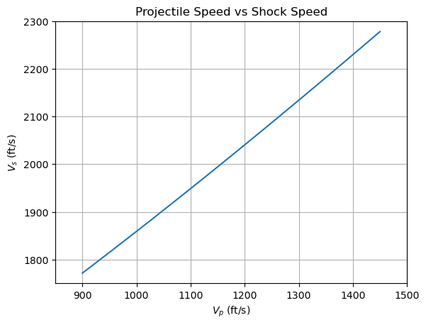

$$ \text{Figure 1. Plot of shock speed as projectile speed varies} \\ \text{between 900 and 1450 ft/s} $$

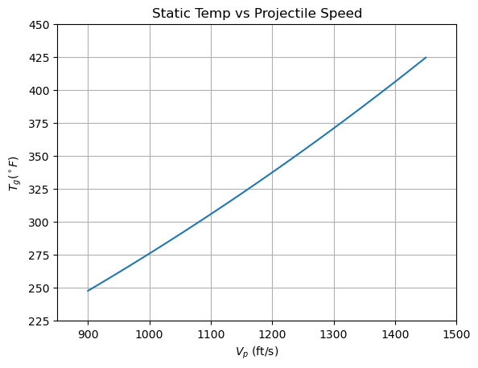

$$ \text{Figure 2. Plot of static temperature after the shock as projectile speed}\\ \text{varies between 900 and 1450 ft/s} $$

### Discussion

We can see that as the projectile speed increases, the shock speed increases. Over this range the relationship between shock and projectile speed is almost linear. It obviously makes sense for shock speed to increase with increasing projectile speed as the projectile is creating the shock so as it speeds up so should the shock.

We can also see that the static temperature increases as projectile speed increases. Over this range the relationship is close to linear but not quite. This relationship makes sense because as the shock passes, it is reducing the speed of the flow and converting its kinetic energy to internal energy. Therefore a higher projectile speed means a faster (and stronger) shock and since velocity is higher, more energy is converted because there is more kinetic energy in the system.

## Problem 2. Shock in Channel

### Given

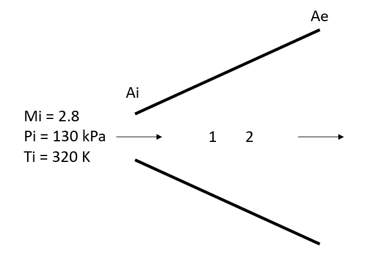

Given the above diagram with $A_e = 5A_i$, plot the back pressure to have a shock at various area ratios and the variation of $M_e$ with shocks at those locations.

### Assumptions

- steady, uniform flow
- isentropic everywhere except shock
- air is CPG with $\gamma=1.4$

### Analysis

We will know the area ratio at each point given by:

$$ \frac{A_1}{A_i} = \frac{A/A^*|M=M_1}{A/A^*|M=M_i} $$

$$ \frac{A}{A^*}|(M=M_1) = (\text{area ratio})\frac{A}{A^*}|(M=2.8) $$

We can calculate the area ratio for the known inlet Mach with: $$ \frac{A}{A^*} =\frac{1}{M}(\frac{1+\frac{\gamma-1}{2}M^2}{\frac{\gamma+1}{2}})^\frac{\gamma+1}{2(\gamma-1)} $$

Using that result, we can find $M_1$ by using a root search algorithm on the area ratio equation with the result plugged in. We will save $M_1$ as the supersonic solution since $M_i$ is supersonic and the area is increasing.

Then we can use $M_1$ to find $M_2$ across the shock: $$ M_2 = \sqrt{\frac{M_1^2+\frac{2}{\gamma-1}}{\frac{2\gamma}{\gamma-1}M_1^2 - 1}} $$

We can get $p_1$ since we know $p_{o1} = p_{oi}$ since the flow is isentropic:

$$ p_{oi} = p_i(1+\frac{\gamma-1}{2}M_i^2)^\frac{\gamma}{\gamma-1} $$

$$ p_1 = p_{oi}/(1+\frac{\gamma-1}{2}M_1^2)^\frac{\gamma}{\gamma-1} $$

Then using both results find $p_2$ across the shock: $$ p_2 = p_1\frac{1+\gamma M_1^2}{1+\gamma M_2^2} $$

Then we can consider area ratios again: $$ \frac{A_2}{A_e} = \frac{A/A^*|M=M_2}{A/A^*|M=M_e} $$

And since we know how $A_i$ is related to $A_e$ and how $A_2=A_1$ is related to $A_i$, we can simplify:

$$ \frac{A}{A^*}|(M=M_e) = (\text{5/area ratio})\frac{A}{A^*}|(M=M_2) $$

Then use the same method as earlier to find the subsonic solution for $M_e$ (since it is after a normal shock).

Lastly, find the required back pressure. We will enforce $p_e=p_b$ and know that $p_{oe}=p_{o2}$ because it is isentropic, so: $$ \frac{p_{oe}}{p_e}=\frac{p_{o2}}{p_b} = (1+\frac{\gamma-1}{2}M_e^2)^\frac{\gamma}{\gamma-1} $$

$$ p_{o2} = p_2(1+\frac{\gamma-1}{2}M_2^2)^\frac{\gamma}{\gamma-1} $$

$$ \fbox{$p_b = p_{o2}/(1+\frac{\gamma-1}{2}M_e^2)^\frac{\gamma}{\gamma-1}$} $$

### Results

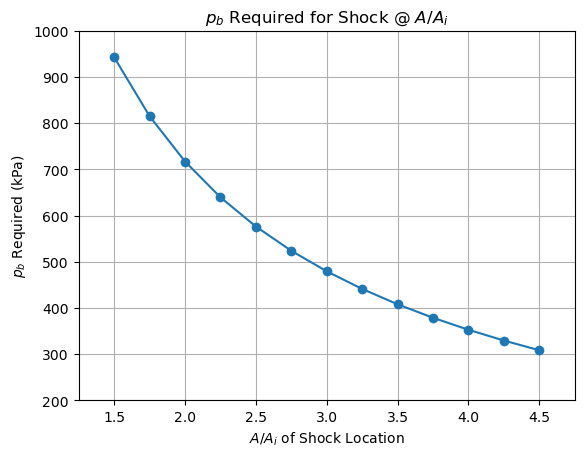

$$ \text{Figure 3. Plot of required back pressure for a shock at the area ratio} \\ \text{varying between 1.5 and 4.5 times inlet area} $$

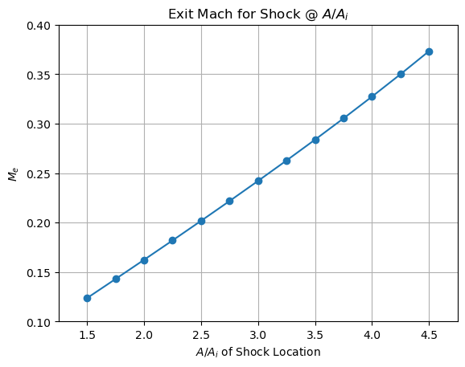

$$ \text{Figure 4. Plot of exit mach number for a shock at the area ratio}\\ \text{varying between 1.5 and 4.5 times inlet area} $$

### Discussion

We can see that the required back pressure is decreasing and asymptoting as the shock moves further into the nozzle. This makes sense as a lower back pressure would allow the flow to get farther before it needed to shock to reach the correct pressure. When the shock is farther back, the pressure of the gas has more time to decrease (as it is an expansion process) and so when it finally shocks the pressure is lower. The asymptotes also make sense. On the left side, the graph will head to infinity as $p_b$ approaches $p_{oi}$, since there would not be flow at that point and the solution becomes undefined. On the right, the asymptote is at the max $p_b$ for the nozzle (the max $p_b$ being the back pressure that creates a shock in the nozzle).

We can also see that the exit mach increases almost linearly as the shock moves further through the nozzle. This also makes sense as the flow will be able to reach a higher Mach number before the shock ($M_1$) since it is supersonic and moving through a section of increasing area. Therefore, once it hits the normal shock and is reduced to subsonic it will be a higher subsonic number because it had more time to accelerate before the shock.

## Problem 3. C-D Nozzle Design

### Given

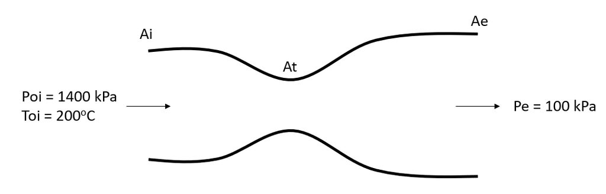

Given the diagram above of a C-D nozzle with a mass flow rate of 3 kg/s, plot the area and Mach number of the nozzle with respect to static pressure.

### Assumptions

- steady, uniform flow
- isentropic
- choked nozzle
- air is CPG with $\gamma=1.4$, $R=287$ J/kgK
- inlet speed is ~0.3

### Analysis

Since the flow is isentropic, we know that all stagnation quanitites are the same everywhere.

We assume that inlet Mach is low. This typically comes from the assumption that the speed of the gas in the combustion chamber or source chamber is close to 0, therefore is small going into the nozzle. We will assume $M_i = 0.3$ arbitrarily.

We can use this inlet mach number to find the static pressure at the inlet: $$ p_i = p_{oi}/(1+\frac{\gamma-1}{2}M_i^2)^\frac{\gamma}{\gamma-1} $$

Then we will take a range from $p_i$ to $p_e$ in increments of 50 kPa and calculate the Mach at each point using the pressure ratio equation:

$$ M = \sqrt{\frac{2((\frac{p_o}{p})^\frac{\gamma-1}{\gamma} - 1)}{\gamma-1}} $$

We can use the sonic back pressure equation (since we are assuming choked flow) to find $p^*$. This will be helpful because we can plot the area from $p_i$ to $p^*$ and then from $p^*$ to $p_b$ to have slightly better results. $$ p^* = p_o(\frac{2}{\gamma+1})^\frac{\gamma}{\gamma-1} $$

Then we can use the Mach number at each point to find the area using the area ratio equation: $$ A = \frac{A^*}{M}(\frac{1+\frac{\gamma-1}{2}M^2}{\frac{\gamma+1}{2}})^\frac{\gamma+1}{2(\gamma-1)} $$

We will find $A^*$ from $\dot{m}$ to use in the area ratio equation above: $$ A^* = \dot{m}_{max}/(\frac{p_o}{\sqrt{RT_o}}\sqrt{\gamma}(1+\frac{\gamma-1}{2})^\frac{\gamma+1}{2(1-\gamma)}) $$

### Results

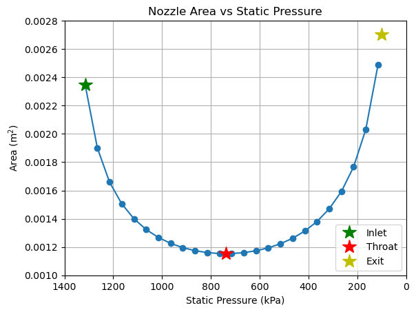

$$ \text{Figure 5. Plot of nozzle area with respect to static pressure} \\ \text{along the nozzle ranging from $p_i$ to $p_e$} $$

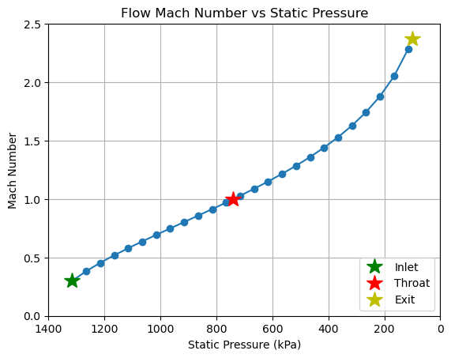

$$ \text{Figure 6. Plot of flow Mach number with respect to static pressure}\\ \text{along the nozzle ranging from $p_i$ to $p_e$} $$

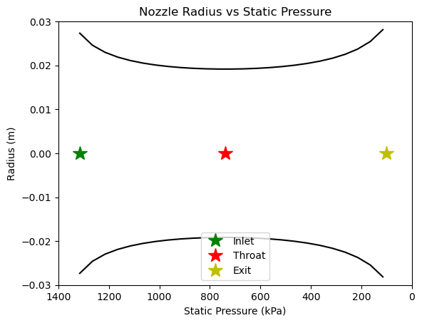

$$ \text{Figure 7. Plot of nozzle radius with respect to static pressure} \\ \text{along the nozzle ranging from $p_i$ to $p_e$} $$

### Discussion

We can see that the area of the nozzle starts large, converges to a minimum at the throat, and then opens up again until the exit. This obviously makes sense for a converging-diverging nozzle, as we want the flow to increase the Mach 1 at the throat (expansion with contracting area for subsonic flow) and then increase above Mach 1 to the exit (expansion with expanding area for supersonic flow).

We can also see the Mach number follows the desired trend, reaching 1 at the throat and then continuing to increase through the diverging section. For a choked nozzle, this is exactly what should happen.

The nozzle is not necessarily a bad design. It is created in such a way that the flow fully expands at the exit (assuming $p_e=p_b$) which is good and it has supersonic exit flow so it achieves its purpose as a nozzle. However, this creates geometry that is not pointing parallel to the free stream. The thrust from the nozzle would be reduced since the exit has such large vertical components. This also means that the flow at the exit will have to turn into itself in order to return to parallel with the free stream around the nozzle (if it is on a vehicle). Since the area is expanding rapidly at the inlet and exit, making geometry that kept the flow parallel would likely require a sharp turn and lead to separation or other losses.